# Internship on Data Science at InfraBIM

## **DS-09: Project - WATER QUALITY PREDICTION**

Internship Reg. No.:3042  
Name:G Aditya Sai  
Date: 15/01/2023

Other Team Members: (Reg.No. - Name)

1. 1030 - Gaini Sumanth
2. 1061 - Gundagani Prudviraj Goud
3. 1047 - G Vamshi Krishna

# **WATER QUALITY PREDICTION**

By G Aditya Sai

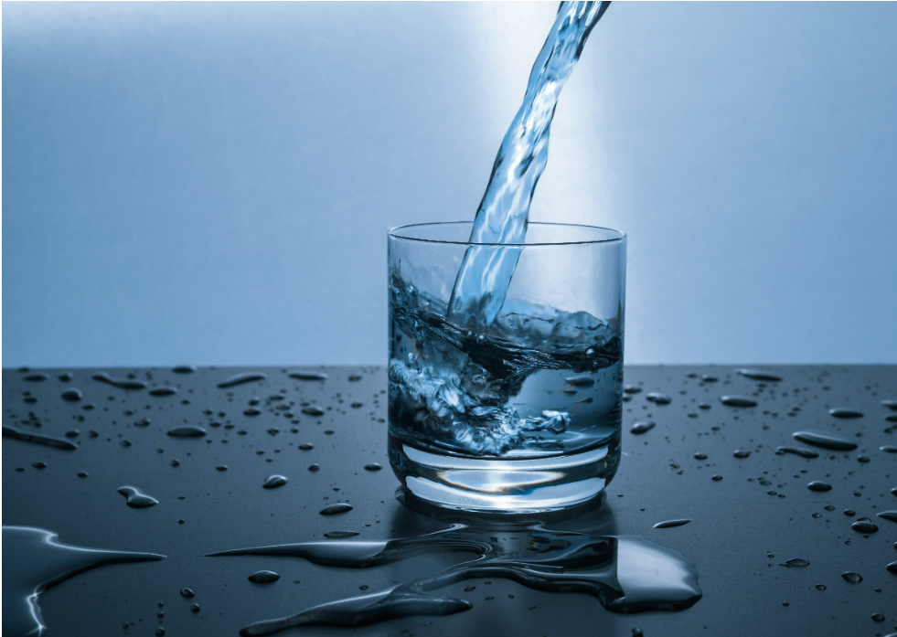

Table Of Contents:

1. Introduction
2. EDA
3. Model Selection and Evaluation
4. Conclusions
5. References

## Introduction

Potable water, also known as drinking water, comes from surface and ground sources and is treated to levels that that meet state and federal standards for consumption.

Water from natural sources is treated for microorganisms, bacteria, toxic chemicals, viruses and fecal matter. Drinking raw, untreated water can cause gastrointestinal problems such as diarrhea, vomiting or fever. Using ML algorithms we can find out that a water is drinkable or not.

### Dataset Description

Dataset was taken from the website kaggle. Access to safe drinking-water is essential to health, a basic human right and a component of effective policy for health protection. This is important as a health and development issue at a national, regional and local level. In some regions, it has been shown that investments in water supply and sanitation can yield a net economic benefit, since the reductions in adverse health effects and health care costs outweigh the costs of undertaking the interventions.

Parameters taken whether the water is drinkable or not:

1. Chemicals that are present in water (Aluminium,Silver,Cadmium etc..)
2. Microorganisms that are present in water(bacteria,virus,etc...)

### 1.2 Importing Packages

```python
import numpy as np
import pandas as pd
import matplotlib.pyplot as plt
import seaborn as sns
```

```python
df = pd.read_csv('https://internships-data.s3.ap-south-1.amazonaws.com/Projects/Data/1099_Water_Quality.csv')
df
```

|  | aluminium | ammonia | arsenic | barium | cadmium | chloramine | chromium | copper | flouride | bacteria | ... | lead | nitrates | nitrites | mercury | perchlorate | radium | selenium | silver | uranium | is_safe |
| --- | --- | --- | --- | --- | --- | --- | --- | --- | --- | --- | --- | --- | --- | --- | --- | --- | --- | --- | --- | --- | --- |
| 0 | 1.65 | 9.08 | 0.04 | 2.85 | 0.007 | 0.35 | 0.83 | 0.17 | 0.05 | 0.20 | ... | 0.054 | 16.08 | 1.13 | 0.007 | 37.75 | 6.78 | 0.08 | 0.34 | 0.02 | 1 |
| 1 | 2.32 | 21.16 | 0.01 | 3.31 | 0.002 | 5.28 | 0.68 | 0.66 | 0.90 | 0.65 | ... | 0.100 | 2.01 | 1.93 | 0.003 | 32.26 | 3.21 | 0.08 | 0.27 | 0.05 | 1 |
| 2 | 1.01 | 14.02 | 0.04 | 0.58 | 0.008 | 4.24 | 0.53 | 0.02 | 0.99 | 0.05 | ... | 0.078 | 14.16 | 1.11 | 0.006 | 50.28 | 7.07 | 0.07 | 0.44 | 0.01 | 0 |
| 3 | 1.36 | 11.33 | 0.04 | 2.96 | 0.001 | 7.23 | 0.03 | 1.66 | 1.08 | 0.71 | ... | 0.016 | 1.41 | 1.29 | 0.004 | 9.12 | 1.72 | 0.02 | 0.45 | 0.05 | 1 |
| 4 | 0.92 | 24.33 | 0.03 | 0.20 | 0.006 | 2.67 | 0.69 | 0.57 | 0.61 | 0.13 | ... | 0.117 | 6.74 | 1.11 | 0.003 | 16.90 | 2.41 | 0.02 | 0.06 | 0.02 | 1 |
| ... | ... | ... | ... | ... | ... | ... | ... | ... | ... | ... | ... | ... | ... | ... | ... | ... | ... | ... | ... | ... | ... |
| 7994 | 0.05 | 7.78 | 0.00 | 1.95 | 0.040 | 0.10 | 0.03 | 0.03 | 1.37 | 0.00 | ... | 0.197 | 14.29 | 1.00 | 0.005 | 3.57 | 2.13 | 0.09 | 0.06 | 0.03 | 1 |
| 7995 | 0.05 | 24.22 | 0.02 | 0.59 | 0.010 | 0.45 | 0.02 | 0.02 | 1.48 | 0.00 | ... | 0.031 | 10.27 | 1.00 | 0.001 | 1.48 | 1.11 | 0.09 | 0.10 | 0.08 | 1 |
| 7996 | 0.09 | 6.85 | 0.00 | 0.61 | 0.030 | 0.05 | 0.05 | 0.02 | 0.91 | 0.00 | ... | 0.182 | 15.92 | 1.00 | 0.000 | 1.35 | 4.84 | 0.00 | 0.04 | 0.05 | 1 |
| 7997 | 0.01 | 10 | 0.01 | 2.00 | 0.000 | 2.00 | 0.00 | 0.09 | 0.00 | 0.00 | ... | 0.000 | 0.00 | 0.00 | 0.000 | 0.00 | 0.00 | 0.00 | 0.00 | 0.00 | 1 |
| 7998 | 0.04 | 6.85 | 0.01 | 0.70 | 0.030 | 0.05 | 0.01 | 0.03 | 1.00 | 0.00 | ... | 0.182 | 15.92 | 1.00 | 0.000 | 1.35 | 4.84 | 0.00 | 0.04 | 0.05 | 1 |

7999 rows × 21 columns

# **2. Exploratory Data Analysis**

```python
df.columns
```

```
Index(['aluminium', 'ammonia', 'arsenic', 'barium', 'cadmium', 'chloramine',
       'chromium', 'copper', 'flouride', 'bacteria', 'viruses', 'lead',
       'nitrates', 'nitrites', 'mercury', 'perchlorate', 'radium', 'selenium',
       'silver', 'uranium', 'is_safe'],
      dtype='object')
```

```python
df.info()
```

```
<class 'pandas.core.frame.DataFrame'>
RangeIndex: 7999 entries, 0 to 7998
Data columns (total 21 columns):
 #   Column       Non-Null Count  Dtype
---  ------       --------------  -----
 0   aluminium    7999 non-null   float64
 1   ammonia      7999 non-null   object
 2   arsenic      7999 non-null   float64
 3   barium       7999 non-null   float64
 4   cadmium      7999 non-null   float64
 5   chloramine   7999 non-null   float64
 6   chromium     7999 non-null   float64
 7   copper       7999 non-null   float64
 8   flouride     7999 non-null   float64
 9   bacteria     7999 non-null   float64
 10  viruses      7999 non-null   float64
 11  lead         7999 non-null   float64
 12  nitrates     7999 non-null   float64
 13  nitrites     7999 non-null   float64
 14  mercury      7999 non-null   float64
 15  perchlorate  7999 non-null   float64
 16  radium       7999 non-null   float64
 17  selenium     7999 non-null   float64
 18  silver       7999 non-null   float64
 19  uranium      7999 non-null   float64
 20  is_safe      7999 non-null   object
dtypes: float64(19), object(2)
memory usage: 1.3+ MB
```

```python
df = df.drop('ammonia',axis=1)
```

```python
df.isnull().sum()
```

```
aluminium      0
arsenic        0
barium         0
cadmium        0
chloramine     0
chromium       0
copper         0
flouride       0
bacteria       0
viruses        0
lead           0
nitrates       0
nitrites       0
mercury        0
perchlorate    0
radium         0
selenium       0
silver         0
uranium        0
is_safe        0
dtype: int64
```

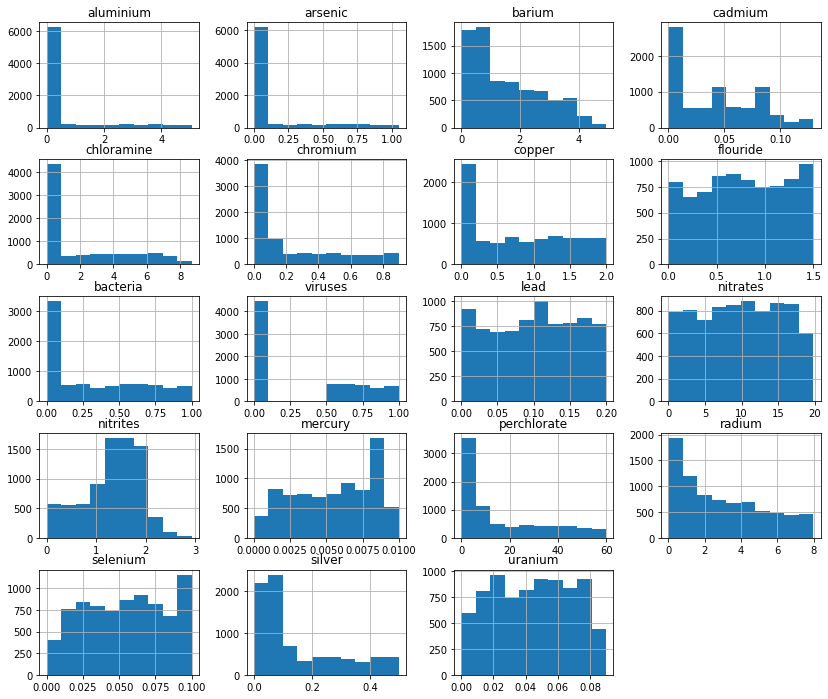

```python
df.hist(figsize=(14,12))
plt.show()
```

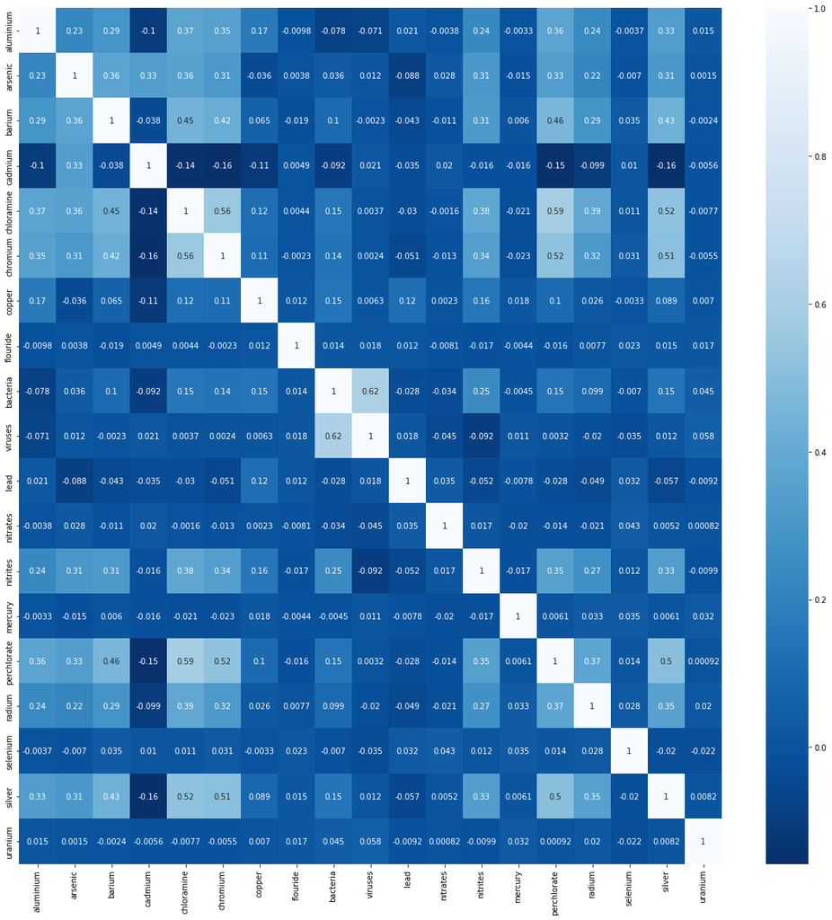

```python
corr_matrix = df.corr(method='pearson')
plt.figure(figsize=(20,20))
sns.heatmap(corr_matrix,annot=True,cmap='Blues_r')
```

# 3. Model Selection and evaluation

**Step 3: Identify Independent and Target Variables**

```python
x = df.iloc[:,:19].values
y = df['is_safe'].values
```

**Step 4: Split the dataset into 80% training data and 20% testing data**

```python
from sklearn.model_selection import train_test_split
x_train,x_test,y_train,y_test = train_test_split(x,y,test_size=0.2)
```

**Step 5: Identify Algorithm**

```python
from sklearn.svm import SVC
model = SVC(kernel='rbf')
```

**Step 6: Fit or Train Model**

```python
model.fit(x_train,y_train)
```

```
SVC()
```

**Step 7: Predict using Test Data**

```python
y_predict = model.predict(x_test)
```

**Step 8: Check Accuracy**

```python
from sklearn.metrics import accuracy_score
accuracy_score(y_test,y_predict)*100
```

```
88.5625
```

```python
model.predict([[0.3,0.5,0.6,0.3,0.2,0.48,0.19,1.5,2.9,0.6,0.5,1.5,1.89,1.5,2.6,3.5,4.2,5.9,1.2]])
```

```
array(['0'], dtype=object)
```

```python
# Plot Test Data with Visualize Prediciton
import pickle
model_name = 'Project_Datalabs-1099.pkl'
pickle.dump(model,open(model_name,'wb'))
```

# 4.Conclusion

This model can help us to detect whether the water is drinkable or not. It has achieved an accuracy of 88.56%.

# 5. References

1. DataSet: Kaggle
2. Case Study:https://www.sciencedirect.com/topics/chemical-engineering/potable-water